# II. Data Analysis for Project 2 ML (OpenFoodFacts)

## Contents

1. Univariate and Bivariate analysis
   1. Checking the products category distribution
   2. Checking nutri-grade and it's correlation with nutri-score
   3. Checking nutri-grade according to the category of the product pnns_group_1
   4. Checking nutri-score according to the sub-category of the product pnns_group_2
   5. Checking the distribution of Nova-score, and its correlation with nutri-grade
   6. Checking Nova-group score according to the category pnns_group_1 of the product
   7. Checking the nutritional contents of the products
   8. Checking the correlation between nutritional contents with each other and with nutri-score
   9. Analysis of Variance (ANOVA)
2. Dimension Reduction: Performing Normalized PCA
   1. Standardize the data
   2. Performing PCA on all nutritional contents of the products
3. Extracting the data
4. Application
5. Conclusion and Future improvement

```python
import numpy as np
import pandas as pd
import matplotlib.pyplot as plt
from matplotlib.collections import LineCollection
import seaborn as sns
import scipy.stats as st
sns.set()
import missingno as msno
import os
from stdnum.ean import *
from sklearn import datasets
from sklearn.decomposition import PCA
from sklearn.preprocessing import StandardScaler
from sklearn.cluster import KMeans

import statsmodels.api
```

```python
OFF_data = pd.read_csv('openfoodfacts_products_data_cleaned.csv',
                       sep='\t', low_memory=False)
print('The size of the table is', OFF_data.shape[0],
      'rows, and', OFF_data.shape[1], 'columns.')
```

```
The size of the table is 1486647 rows, and 17 columns.
```

```python
OFF_data.describe(include='all')
```

|  | code | product_name | brands | pnns_groups_1 | pnns_groups_2 | nutriscore_grade | nutriscore_score | nova_group | energy | fat | saturated_fat | carbohydrates | sugars | fiber | proteins | sodium | fruits_vegetables_nuts |
| --- | --- | --- | --- | --- | --- | --- | --- | --- | --- | --- | --- | --- | --- | --- | --- | --- | --- |
| count | 1.486647e+06 | 1486647 | 1486647 | 1486647 | 1486647 | 1486647 | 1.486647e+06 | 1.486647e+06 | 1.486647e+06 | 1.486647e+06 | 1.486647e+06 | 1.486647e+06 | 1.486647e+06 | 1.486647e+06 | 1.486647e+06 | 1.486647e+06 | 1.486647e+06 |
| unique | NaN | 1204764 | 164871 | 10 | 40 | 5 | NaN | NaN | NaN | NaN | NaN | NaN | NaN | NaN | NaN | NaN | NaN |
| top | NaN | Spaghetti | unknown | Sugary snacks | One-dish meals | d | NaN | NaN | NaN | NaN | NaN | NaN | NaN | NaN | NaN | NaN | NaN |
| freq | NaN | 392 | 606601 | 347360 | 195786 | 473105 | NaN | NaN | NaN | NaN | NaN | NaN | NaN | NaN | NaN | NaN | NaN |
| mean | 3.873754e+12 | NaN | NaN | NaN | NaN | NaN | 9.990958e+00 | 3.655283e+00 | 2.766502e+02 | 1.339152e+01 | 4.924982e+00 | 3.034248e+01 | 1.355497e+01 | 1.574076e+00 | 8.483340e+00 | 4.839173e-01 | 3.265502e+00 |
| std | 3.164964e+12 | NaN | NaN | NaN | NaN | NaN | 8.666456e+00 | 8.151770e-01 | 1.735458e+02 | 1.578414e+01 | 7.115724e+00 | 2.693584e+01 | 1.877048e+01 | 2.769936e+00 | 9.496268e+00 | 1.730145e+00 | 1.363307e+01 |
| min | 1.700000e+01 | NaN | NaN | NaN | NaN | NaN | -1.400000e+01 | 1.000000e+00 | 0.000000e+00 | 0.000000e+00 | 0.000000e+00 | 0.000000e+00 | 0.000000e+00 | 0.000000e+00 | 0.000000e+00 | 0.000000e+00 | 0.000000e+00 |
| 25% | 7.048630e+11 | NaN | NaN | NaN | NaN | NaN | 2.000000e+00 | 4.000000e+00 | 1.290000e+02 | 1.500000e+00 | 2.000000e-01 | 5.600000e+00 | 1.000000e+00 | 0.000000e+00 | 2.000000e+00 | 4.400000e-02 | 0.000000e+00 |
| 50% | 3.595182e+12 | NaN | NaN | NaN | NaN | NaN | 1.100000e+01 | 4.000000e+00 | 2.665154e+02 | 8.700000e+00 | 2.200000e+00 | 2.333333e+01 | 4.700000e+00 | 1.000000e+00 | 6.150000e+00 | 2.400000e-01 | 0.000000e+00 |
| 75% | 7.451078e+12 | NaN | NaN | NaN | NaN | NaN | 1.600000e+01 | 4.000000e+00 | 3.940000e+02 | 2.000000e+01 | 6.500000e+00 | 5.357000e+01 | 1.780000e+01 | 1.500000e+00 | 1.160000e+01 | 4.800000e-01 | 0.000000e+00 |
| max | 9.540014e+13 | NaN | NaN | NaN | NaN | NaN | 4.000000e+01 | 4.000000e+00 | 9.000000e+02 | 1.000000e+02 | 1.000000e+02 | 1.000000e+02 | 1.000000e+02 | 1.000000e+02 | 1.000000e+02 | 9.398000e+01 | 1.000000e+02 |

## 1. Univariate and Bivariate analysis

### A. Checking the products category distribution

```
pnns_groups_1            pnns_groups_2
Alcoholic beverages      Alcoholic beverages                  10564
                         unknown                                 25
Beverages                Artificially sweetened beverages     11517
                         Fruit juices                         12383
                         Fruit nectars                         2236
                         Plant-based milk substitutes         10624
                         Sweetened beverages                  35539
                         Teas and herbal teas and coffees      1518
                         Unsweetened beverages                14721
                         Waters and flavored waters           20981
                         unknown                                 53
Cereals and potatoes     Bread                                50889
                         Breakfast cereals                    17374
                         Cereals                              93901
                         Legumes                              14545
                         Potatoes                              6952
                         unknown                                  3
Composite foods          One-dish meals                      195786
                         Pizza pies and quiches               20165
                         Sandwiches                            7588
                         unknown                                  2
Fat and sauces           Dressings and sauces                 84214
                         Fats                                 21557
Fish Meat Eggs           Eggs                                  4510
                         Fish and seafood                     48720
                         Meat                                 48591
                         Offals                                1095
                         Processed meat                       69276
                         unknown                                 29
Fruits and vegetables    Dried fruits                          8373
                         Fruits                               26240
                         Soups                                 9989
                         Vegetables                           52303
                         unknown                                  1
Milk and dairy products  Cheese                               64443
                         Dairy desserts                       13026
                         Ice cream                            26728
                         Milk and yogurt                      54120
                         unknown                                  1
Salty snacks             Appetizers                           39602
                         Nuts                                 21962
                         Salty and fatty products             17141
Sugary snacks            Biscuits and cakes                  190652
                         Chocolate products                   32572
                         Pastries                             10181
                         Sweets                              113955
dtype: int64
```

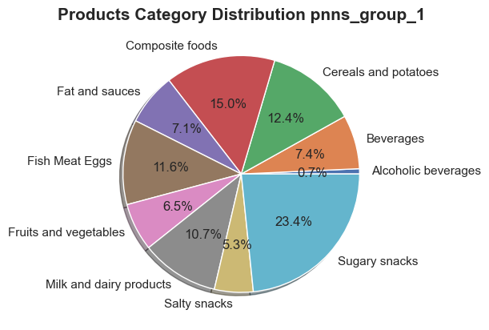

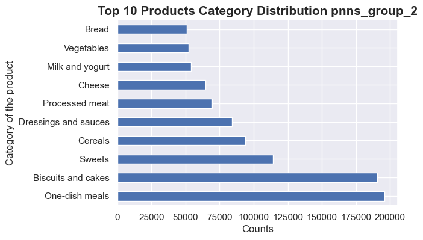

```python
display((OFF_data[['pnns_groups_1', 'pnns_groups_2']]).groupby(['pnns_groups_1', 'pnns_groups_2']).size())

plt.pie(OFF_data[(OFF_data['pnns_groups_1'] != 'unknown')].groupby(by='pnns_groups_1').nunique()['code'],
        labels=OFF_data[(OFF_data['pnns_groups_1'] != 'unknown')].groupby(by='pnns_groups_1').nunique()['code'].index,
        startangle=0,
        shadow=True,
        autopct='%1.1f%%')
plt.title('Products Category Distribution pnns_group_1', fontsize=15, fontweight='bold')
plt.show()

plt.figure(figsize = (6, 4))
OFF_data[(OFF_data['pnns_groups_2'] != 'unknown')].groupby(by='pnns_groups_2').nunique().sort_values('code', ascending=False)['code'].head(10).plot(kind='barh')
plt.title('Top 10 Products Category Distribution pnns_group_2', fontsize=15, fontweight='bold')
plt.xlabel('Counts')
plt.ylabel('Category of the product')
plt.show()
```

Observations:

- pnns_group_1:
  - Most category are well represented, only Alcoholic beverages have very low representation of products.
  - Sugary snacks occupy the highest percentage of products followed by Composite foods, Cereals and potatoes, Fish Meats Eggs, and Milk and dairy products.
- pnns_group_2:
  - We see One-dish meals being the most represented which is linked to pnns_group_1 Composite foods.
  - We see the correlation between the top 1 pnns_group_1 and the top 3 category Biscuits and cakes, and Sweets in pnns_group_2. Both are linked together in our database.
  - Cereals are next which are linked to Cereals and postatoes in pnns_group_1.
  - This is followed by Dressings and sauces which are linked to Fat and Sauces in pnns_group_1

### B. Checking nutri-grade and it's correlation with nutri-score

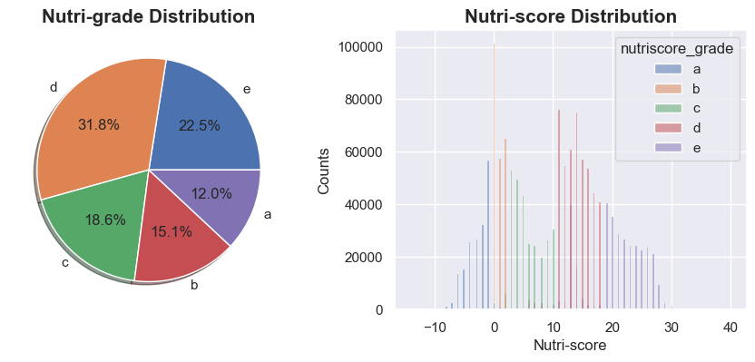

```python
fig, axes = plt.subplots(1, 2, figsize=(11,4))
axes[0].pie(OFF_data.groupby(by='nutriscore_grade').nunique().sort_values('nutriscore_grade', ascending=False)['code'],
        labels=OFF_data.groupby(by='nutriscore_grade').nunique().sort_values('nutriscore_grade', ascending=False)['code'].index,
        startangle=0,
        shadow=True,
        autopct='%1.1f%%')
axes[0].set_title('Nutri-grade Distribution', fontsize=15, fontweight='bold')
sns.histplot(data=OFF_data.sort_values('nutriscore_grade'), x='nutriscore_score', hue='nutriscore_grade', ax=axes[1])
axes[1].set_title('Nutri-score Distribution', fontsize=15, fontweight='bold')
axes[1].set_xlabel('Nutri-score')
axes[1].set_ylabel('Counts')
plt.show()
```

Observations:

- On nutri-grade, we see that grades d and e occupy more than half of the products on our database meaning that there is considerable presence of products with low nutritional value. The products with good nutritional value, i.e. a and b grades, occupy little bit more than 25% of the products.
- For the nutriscore, we can see from the distribution two peaks centered around 0 (corresponding to around b nutri-grade) and 14 (corresponding to around d nutri-grade).
- Additionnaly, the nutri-score distribution according to the nutri-grade show the high correlation between the nutri-score and the nutri-grade.

### C. Checking nutri-grade according to the category of the product pnns_group_1

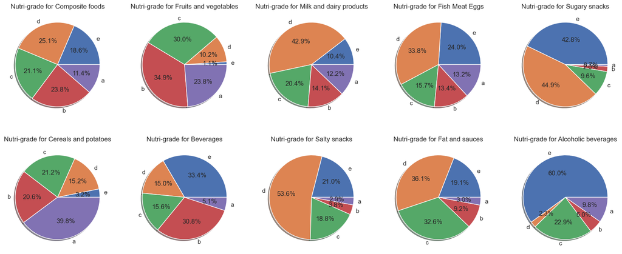

```python
n_sub = len(OFF_data['pnns_groups_1'].unique())
n_col = 5
fig, axes = plt.subplots(int(round((0.49+n_sub/n_col), 0)), n_col, figsize=(20, int(0.8*n_sub)))
axes = np.array(axes)
i = 0
for ax in axes.reshape(-1):
    cat = OFF_data['pnns_groups_1'].unique()[i]
    subset = OFF_data[OFF_data['pnns_groups_1']==cat].groupby(by='nutriscore_grade').nunique().sort_values('nutriscore_grade', ascending=False)
    ax.pie(subset['code'],
           labels=subset['code'].index,
           startangle=0,
           shadow=True,
           autopct='%1.1f%%')
    ax.set_title('Nutri-grade for {}'.format(cat))
    i += 1
plt.show()
```

Observations:

Note that Milk and dairy, Fish Meat Eggs products are mostly labeled with bad nutri-garde. We will analyse the pnns_group_2 distribution according to the nutri-score to identify which sub-categories of the main category Milk and dairy, and Fish Meat Eggs are good and which are bad.

### D. Checking nutri-score according to the sub-category of the product pnns_group_2

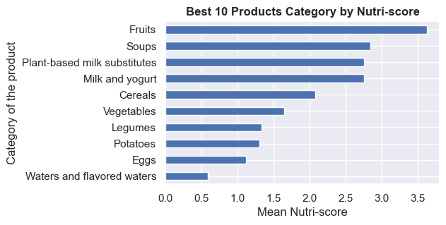

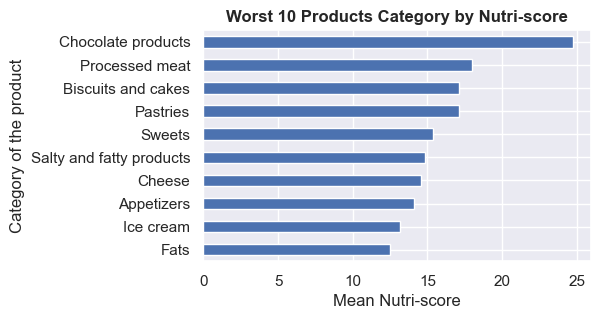

```python
plt.figure(figsize = (5,3))
OFF_data.groupby(by='pnns_groups_2')['nutriscore_score'].mean().sort_values().head(10).plot(kind='barh')
plt.title('Best 10 Products Category by Nutri-score', fontsize=12, fontweight='bold')
plt.xlabel('Mean Nutri-score')
plt.ylabel('Category of the product')
plt.show()
plt.figure(figsize = (5,3))
OFF_data.groupby(by='pnns_groups_2')['nutriscore_score'].mean().sort_values().tail(10).plot(kind='barh')
plt.title('Worst 10 Products Category by Nutri-score', fontsize=12, fontweight='bold')
plt.xlabel('Mean Nutri-score')
plt.ylabel('Category of the product')
plt.show()
```

Observations:

- The sub-category of products with best nutri-score: eau, Legumes, Eggs, Potatoes, Vegetables, Cereals, Milk and yogurt, Soups, plant based milk subsitutes, and Fruits.
- The category of products with worst nutri-score: Chocolate products, processed meat, biscuits and cakes, Pastries, Sweets, salty and fatty products, cheese, appetizers, ice cream, and fats.

We see that for pnns_group_1 Milk and dairy, milk and yogurt are categorized with mostly good score and cheese and Ice cream are categrized mostly with bad score. For pnns_group_1 Fish Meat Eggs, eggs is categorized with good score, and processed meat with mostly bad score.

### E. Checking the distribution of Nova-score, and its correlation with nutri-grade

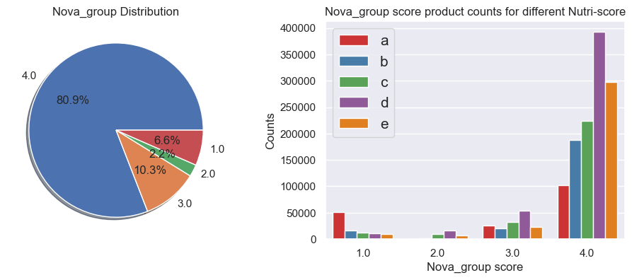

```python
fig, axes = plt.subplots(1, 2, figsize=(12,4))
axes[0].pie(OFF_data.groupby(by='nova_group').nunique().sort_values('nova_group', ascending=False)['code'],
        labels=OFF_data.groupby(by='nova_group').nunique().sort_values('nova_group', ascending=False)['code'].index,
        startangle=0,
        shadow=True,
        autopct='%1.1f%%')
axes[0].set_title('Nova_group Distribution')
sns.countplot(x=OFF_data['nova_group'],
              hue= OFF_data['nutriscore_grade'],
              data= OFF_data,
              palette='Set1',
              hue_order=OFF_data['nutriscore_grade'].sort_values().unique(),
              ax = axes[1])
axes[1].legend(loc='upper left', fontsize=15)
axes[1].set_xlabel('Nova_group score')
axes[1].set_ylabel('Counts')
axes[1].set_title('Nova_group score product counts for different Nutri-score')
plt.show()
```

Observations:

- For the nova score, most of value are 4 corresponding to highly processed food.
- From the countplot, we see that there is sligh correlation between nutri_score and nova_score; We see that the less the food is processed (i.e. lower nova score) the better its nutritional quality (i.e. a and b score dominance).

### F. Checking Nova-group score according to the category pnns_group_1 of the product

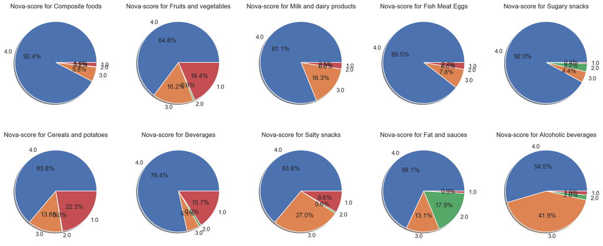

```python
n_sub = len(OFF_data['pnns_groups_1'].unique())
n_col = 5
fig, axes = plt.subplots(int(round((0.49+n_sub/n_col), 0)), n_col, figsize=(20, int(0.8*n_sub)))
axes = np.array(axes)
i = 0
for ax in axes.reshape(-1):
    cat = OFF_data['pnns_groups_1'].unique()[i]
    subset = OFF_data[OFF_data['pnns_groups_1'] == cat].groupby(by='nova_group').nunique().sort_values('nova_group', ascending=False)
    ax.pie(subset['code'],
           labels=subset['code'].index,
           startangle=0,
           shadow=True,
           autopct='%1.1f%%')
    ax.set_title('Nova-score for {}'.format(cat))
    i += 1
plt.show()
```

Observations:

- Nova score of 1 (not processed product) becomes significant in Fruits and legumes, and Cereals and potatoes.
- Nova score of 4 is dominating all products categories.
- Fruits and legumes, as well as Fish Meat Eggs should mostly be at a score of 1, however the dominance of score 4 in those two categories tell us that nova_group score is not to be trusted parameter in our database.

We will drop the nova_group score from the database since it can't be trusted.

```python
OFF_data.drop(['nova_group'], axis=1, inplace=True)
```

### G. Checking the nutritional contents of the products

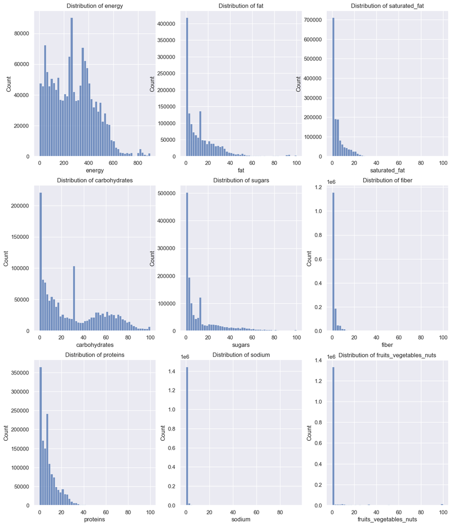

```python
columns_list=OFF_data[[column for column in OFF_data.select_dtypes(include='float64').columns if (column != 'nutriscore_score')]].columns
n_sub = len(columns_list)
n_col = 3
fig, axes = plt.subplots(int(round((0.49+n_sub/n_col), 0)), n_col, figsize=(15, int(2*n_sub)))
axes = np.array(axes)
i = 0
for ax in axes.reshape(-1):
    sns.histplot(data=OFF_data[columns_list[i]], bins=50, ax=ax)
    ax.set_title('Distribution of {}'.format(columns_list[i]))
    i += 1
plt.show()
```

Observations:

```
- None of the nutritional contents have Gaussian distribution. We see the dominance of 0 or very low values on all columns except in energy column.
- We see that fruits-vegetables-nuts percentage is almost 0 on most of the products and very few products have 100%. We will check this column against pnns_group_1 Fruits and vegetables category to decide if we keep it or not.
```

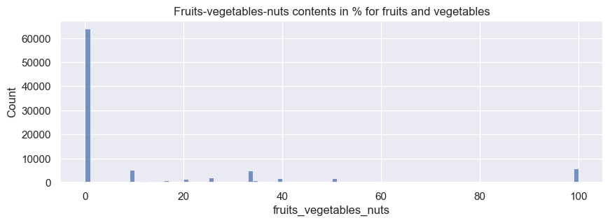

```python
plt.figure(figsize=(10, 3))
sns.histplot(data=OFF_data[OFF_data['pnns_groups_1'] == 'Fruits and vegetables']['fruits_vegetables_nuts'], bins=100)
plt.title('Fruits-vegetables-nuts contents in % for fruits and vegetables')
plt.show()
```

```
- We see that still the majority of the products have 0% contents in the category fruits amd vegetables. The majority of the products in that category should have 100% value. This tell us that fruits-vegetables-nuts column cannot be trusted. We will drop it from the database.
```

```python
OFF_data.drop(['fruits_vegetables_nuts'], axis=1, inplace=True)
```

### H. Checking the correlation between nutritional contents with each other and with nutri-score

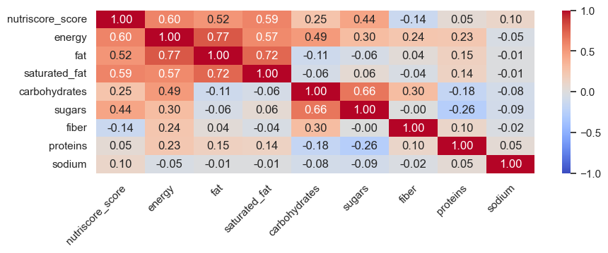

```python
plt.figure(figsize = (10, 3))
sns.heatmap(OFF_data.select_dtypes(include='float64').corr(method='pearson'),
            vmin=-1, vmax=1, annot=True, cmap='coolwarm', fmt="0.2f")
plt.xticks(ha='right', rotation=45, rotation_mode='anchor')
plt.show()
```

Observations:

- Nutrional contents correlation with each others:
  - There is high positive correlation between fat and energy which is logic. Fat is the most dense product on energy with 9Kcal/g.
  - There is high positive correlation as well between saturated_fat and fat which is logic because saturated_fat belong to fat macronutrients. This tell us as well that the products saturated_fat contents highly follows the fat contents.
  - There is high correlation as well between sugars and carbohydrates which is logic because they belong to the same group. This tell us as well that the products sugars contents highly follows the carbohydrates contents. We see as well that fiber follow carbohydrate by to a lesser degree than sugars.
- Nutrional contents correlation to nutri-score:
  - There is positive correlation of energy, fat, saturated_fat, sugars, and to a lesser degree carbohydrates with the nutri-score which is logic. Products with good nutritional value (low nutri-score) are low on energy, fat, saturated_fat, and sugars.
  - There is slight negative correlation of fiber with the nutri-score which is logic as well. Products high on fiber provide good nutritional value.
  - There is no or very small positive correlation of protein and sodium with nutri-score.

### I. Analysis of Variance (ANOVA)

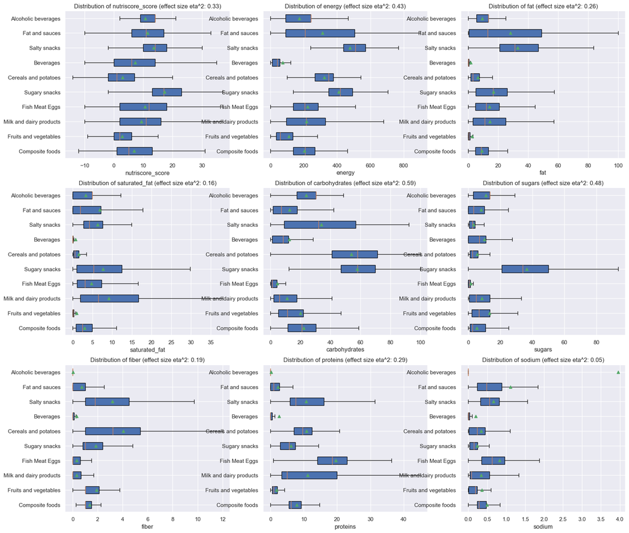

```python
# Measuring of effect size, eta squared between two variables, one qualitative and one quantitative.
def eta_squared(x, y):
    moyenne_y = y.mean()
    classes = []
    for classe in x.unique():
        yi_classe = y[x == classe]
        classes.append({'ni': len(yi_classe),
                        'moyenne_classe': yi_classe.mean()})
    SCT = sum([(yj-moyenne_y)**2 for yj in y])
    SCE = sum([c['ni']*(c['moyenne_classe']-moyenne_y)**2 for c in classes])
    return round(SCE/SCT, 2)

# Plotting the distributions of quantitative columns for each pnns_group_1 category
columns_list = OFF_data.select_dtypes(include='float64').columns
n_sub = len(columns_list)
n_col = 3
fig, axes = plt.subplots(int(round((0.49+n_sub/n_col), 0)), n_col, figsize=(20, int(2*n_sub)))
axes = np.array(axes)
i = 0
for ax in axes.reshape(-1):
    groupes = []
    for m in OFF_data['pnns_groups_1'].unique():
        groupes.append(OFF_data[OFF_data['pnns_groups_1'] == m][columns_list[i]])
    eta_squared_value = eta_squared(OFF_data['pnns_groups_1'], OFF_data[columns_list[i]])
    ax.boxplot(groupes, labels=OFF_data['pnns_groups_1'].unique(),
               showfliers=False, vert=False, patch_artist=True, showmeans=True)
    ax.set_title('Distribution of {} (effect size eta^2: {})'.format(columns_list[i], eta_squared_value))
    ax.set_xlabel(format(columns_list[i]))
    i+=1
plt.show()
```

Observations:

- For the **nutriscore** distribution, as discussed before, fruit and vegetables, and cereals and potatoes have better nutri-score than other categories. Sugary snacks have bad nutri-score.
- For the **energy** distribution, Beverages have low energy which is logic due to their liquid state. We see that Salty snacks and sugary snacks have high energy because they are dense on sugar and fat.
- For the **fat** distribution, beverages, fruits and vegetables are low on fat which is logic. We seee that salty snacks high on fat which validate the previous point of salty snacks being high on energy as well. This is followed by fat and sauces as being high on fat.
- For the **saturated-fat** ditribution, beverages, fuits and vegetables are again low on saturated-fat. Milk and dairy products are high on saturated fat which is known phenomena.
- For the **carbohydrates** distribution, Fish meats and eggs are low on carbohydrates which is logic because these products are known to be sources of protein and fat. Sugary snacks, cereals and potatoes are high on carbohydrate which is again logic because sugary snacks are known to be high on sugars and cerals and potatoes to be a sources of carbohydrates.
- For the **sugars** distribution, we see sugary snacks to be the top of the podium since these products are known to be high on sugars.
- For the **fiber** distribution, we see fruits and vegetables, cereals and potatoes, and salty snacks to be high on fibers.
- For the **proteins** distribution, we see fish meats eggs, and milk and dairy products being high on protein which is logic.
- For the **sodium** distribution, we see that fat and sauces, salty snacks, fish meat eggs to be higher on sodium than other.

From the value of effect size eta_squared, we see that there is big effect of the category of the products and the carbohydrates and sugars (highest eta_squared value). We see that sodium has the lowest effect from the category of the products (near zero eta_squared).

Now we can do the same but this time using the **top 10 pnns_group_2** sub-category of the product.

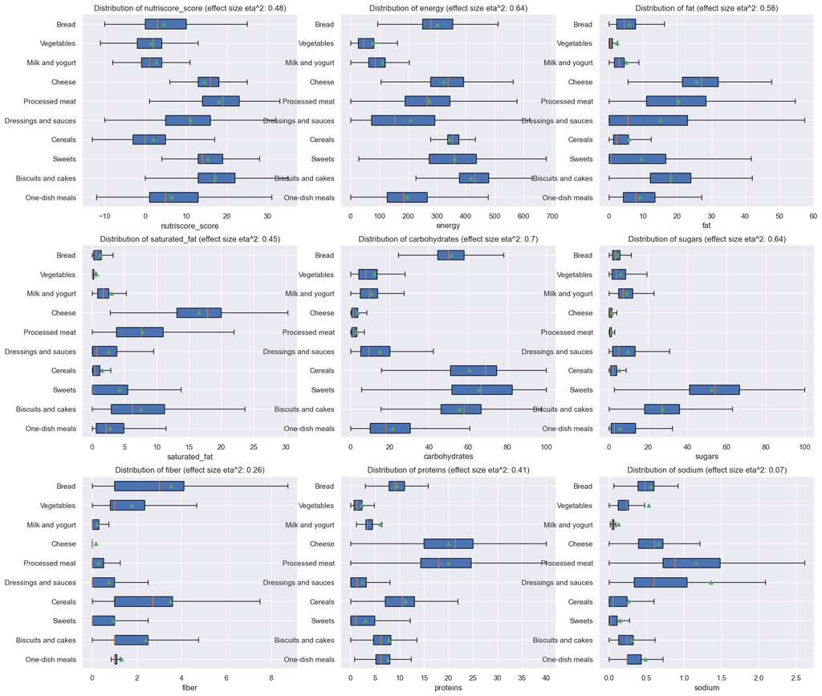

```python
# Plotting the distributions of quantitative columns for each pnns_group_2 sub-category
columns_list = OFF_data.select_dtypes(include='float64').columns
n_sub = len(columns_list)
n_col = 3
fig, axes = plt.subplots(int(round((0.49+n_sub/n_col), 0)), n_col, figsize=(20, int(2*n_sub)))
axes = np.array(axes)
i = 0
top_pnns_group_list = OFF_data[(OFF_data['pnns_groups_2'] != 'unknown')].groupby(by='pnns_groups_2').nunique().sort_values('code', ascending=False).head(10).index
for ax in axes.reshape(-1):
    groupes = []
    for m in top_pnns_group_list:
        groupes.append(OFF_data[OFF_data['pnns_groups_2'] == m][columns_list[i]])
    eta_squared_value = eta_squared(OFF_data['pnns_groups_2'], OFF_data[columns_list[i]])
    ax.boxplot(groupes, labels=top_pnns_group_list, showfliers=False,
               vert=False, patch_artist=True, showmeans=True)
    ax.set_title('Distribution of {} (effect size eta^2: {})'.format(columns_list[i], eta_squared_value))
    ax.set_xlabel(format(columns_list[i]))
    i += 1
plt.show()
```

Now we can do statistical test to check the correlation between nutri-score and pnns_group_2.

```
Test the null hypothesis (H0) that all products means are equal vs. the alternative hypothesis (Ha) that at least one mean is different.
```

```python
# Statistical test
fit = statsmodels.formula.api.ols('nutriscore_score ~ pnns_groups_2', data=OFF_data).fit()
table = statsmodels.api.stats.anova_lm(fit)
print(table)
```

```
                      df        sum_sq       mean_sq             F  PR(>F)
pnns_groups_2       39.0  5.364700e+07  1.375564e+06  35250.499017     0.0
Residual       1486607.0  5.801119e+07  3.902255e+01           NaN     NaN
```

Now we can do the same but this time using the nutri-grade instead of the category or sub-category of the product.

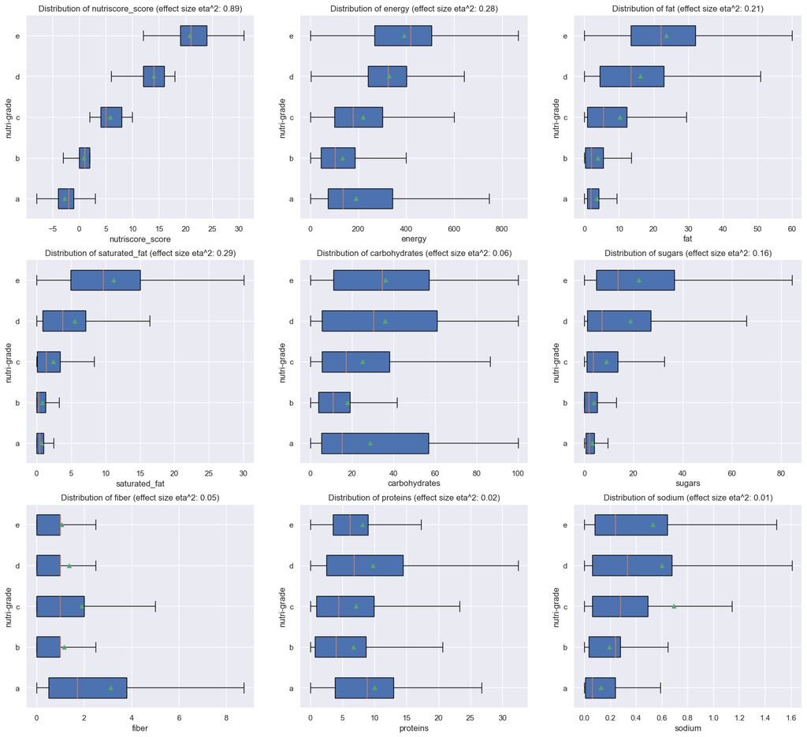

```python
# Plotting the distributions of nutri-grade for each
columns_list = OFF_data.select_dtypes(include='float64').columns
n_sub = len(columns_list)
n_col = 3
fig, axes = plt.subplots(int(round((0.49+n_sub/n_col), 0)), n_col, figsize=(20, int(2*n_sub)))
axes = np.array(axes)
i = 0
for ax in axes.reshape(-1):
    groupes = []
    for m in OFF_data['nutriscore_grade'].sort_values().unique():
        groupes.append(OFF_data[OFF_data['nutriscore_grade'] == m][columns_list[i]])
    eta_squared_value = eta_squared(OFF_data['nutriscore_grade'], OFF_data[columns_list[i]])
    ax.boxplot(groupes, labels=OFF_data['nutriscore_grade'].sort_values().unique(), showfliers=False,
               vert=False, patch_artist=True, showmeans=True)
    ax.set_title('Distribution of {} (effect size eta^2: {})'.format(columns_list[i], eta_squared_value))
    ax.set_xlabel(format(columns_list[i]))
    ax.set_ylabel('nutri-grade')
    i += 1
plt.show()
```

Observations:

- For the **nutri-score**, we see gain the **high correlation with nutri-garde** which is manifested by the distribution and the value of eta-squared of almost 1.
- For the **energy** distribution, we see **small correlation with nutri-garde**. This is also meaured by the effect size which is not high but not negligeable. We see that **a and b grade have lower energy than d and e grade**.
- For the **fat** and **saturated-fat** distribution, we can conclude, similar to energy, **small correlation to nutri-grade** with not high effect size and **a and b grade have lower fat and saturated_fat than d and e grade** which is logic.
- For the **carbohydrate** and **fiber** distribution, we see **very low correlation with nutri-grade** which is also shown by the effect size eta_sauqred value of near zero.
- For the **sugars**, we see **small correlation with nutri-garde** and not high eta_squared value. Again **a and b grade have lower sugars contents than d and e grade**.
- Finally for the **proteins** and **sodium**, we can conclude similar to carbohydrate and fiber that they have **very low to no correlation to nutri-grade** with eta_squared value near-zero.

Now we can do statistical test to check some of these correlation.

```
Test the null hypothesis (H0) that all products means are equal vs. the alternative hypothesis (Ha) that at least one mean is different.
```

```python
# Statistical test
fit = statsmodels.formula.api.ols('nutriscore_score ~ nutriscore_grade', data=OFF_data).fit()
table = statsmodels.api.stats.anova_lm(fit)
print('For nutriscore_score:')
print(table, '\n')
fit = statsmodels.formula.api.ols('fat ~ nutriscore_grade', data=OFF_data).fit()
table = statsmodels.api.stats.anova_lm(fit)
print('For fat:')
print(table, '\n')
fit = statsmodels.formula.api.ols('sugars ~ nutriscore_grade', data=OFF_data).fit()
table = statsmodels.api.stats.anova_lm(fit)
print('For sugars:')
print(table)
```

```
For nutriscore_score:
                         df        sum_sq       mean_sq             F  PR(>F)
nutriscore_grade        4.0  9.896212e+07  2.474053e+07  2.896982e+06     0.0
Residual          1486642.0  1.269608e+07  8.540105e+00           NaN     NaN

For fat:
                         df        sum_sq       mean_sq             F  PR(>F)
nutriscore_grade        4.0  7.904199e+07  1.976050e+07  100833.46134     0.0
Residual          1486642.0  2.913397e+08  1.959716e+02           NaN     NaN

For sugars:
                         df        sum_sq       mean_sq             F  PR(>F)
nutriscore_grade        4.0  8.358140e+07  2.089535e+07  70566.088687     0.0
Residual          1486642.0  4.402101e+08  2.961104e+02           NaN     NaN
```

This test validate our observation that there is effect between sugars and fat with nutri-grade. Additionally, the nutri-score and nutri-grade are highly correlated (highest F).

## 2. Dimension Reduction: Performing Normalized PCA

### A. Standardize the data

We select the columns with nutritional contents

```python
columns_pca = ['energy', 'fat', 'saturated_fat', 'carbohydrates',
               'sugars', 'fiber', 'proteins', 'sodium']
# Centering and reducing the data by making all columns having the same power (same mean value and same standart deviation value).
OFF_data_scaled = pd.DataFrame(StandardScaler().fit_transform(OFF_data[columns_pca]))
OFF_data_scaled.columns = columns_pca
OFF_data_scaled.describe().round(2)
```

|  | energy | fat | saturated_fat | carbohydrates | sugars | fiber | proteins | sodium |
| --- | --- | --- | --- | --- | --- | --- | --- | --- |
| count | 1486647.00 | 1486647.00 | 1486647.00 | 1486647.00 | 1486647.00 | 1486647.00 | 1486647.00 | 1486647.00 |
| mean | 0.00 | 0.00 | -0.00 | -0.00 | 0.00 | 0.00 | 0.00 | -0.00 |
| std | 1.00 | 1.00 | 1.00 | 1.00 | 1.00 | 1.00 | 1.00 | 1.00 |
| min | -1.59 | -0.85 | -0.69 | -1.13 | -0.72 | -0.57 | -0.89 | -0.28 |
| 25% | -0.85 | -0.75 | -0.66 | -0.92 | -0.67 | -0.57 | -0.68 | -0.25 |
| 50% | -0.06 | -0.30 | -0.38 | -0.26 | -0.47 | -0.21 | -0.25 | -0.14 |
| 75% | 0.68 | 0.42 | 0.22 | 0.86 | 0.23 | -0.03 | 0.33 | -0.00 |
| max | 3.59 | 5.49 | 13.36 | 2.59 | 4.61 | 35.53 | 9.64 | 54.04 |

### B. Performing PCA on all nutritional contents of the products

We choose 8 principal components at first.

```python
# Doing a PCA on the data
pca_n_components = len(OFF_data_scaled.columns)
pca = PCA(pca_n_components)
pca.fit(OFF_data_scaled)
OFF_data_scaled_pca = pca.transform(OFF_data_scaled)
```

```python
def scree_plot_explained_variance_ratio(pca_n_components):  # Plotting explained variance ratio in scree plot
    exp_var_rat = pca.explained_variance_ratio_
    x_list = range(1, pca_n_components+1)
    x_list_name = [f"F{i}" for i in x_list]
    plt.grid(False)
    plt.bar(x_list_name, exp_var_rat)
    ax1 = plt.gca()
    ax1.set(ylim=(0,exp_var_rat.max()*1.1))
    ax2 = ax1.twinx()
    ax2.plot(x_list_name, exp_var_rat.cumsum(), c='red', marker='o')
    ax2.set(ylim=(0, 1.1))
    ax1.set_ylabel('Explained Variance Ratio')
    ax2.set_ylabel('Cumulative Explained Variance Ratio')
    ax1.set_xlabel('Principal Components')

    for i, p in enumerate(ax1.patches):
        ax1.text( p.get_width()/5 + p.get_x(), p.get_height()+ p.get_y()+0.01,
                 '{:.0f}%'.format(exp_var_rat[i]*100),
                 fontsize=8, color='k')

    plt.gcf().set_size_inches(8, 3)
    plt.title('Scree plot', fontweight='bold')
    plt.grid(False)
    plt.show()
```

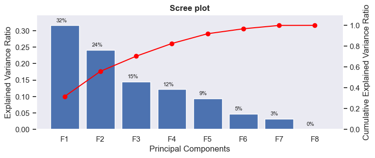

```python
scree_plot_explained_variance_ratio(pca_n_components)
```

We can see that most of the informations is contained in the first 5 componants (around 92%), we can reduce dimentially without losing much informations by discarding the components with low informations. I'm going to discard all component higher than 5 and redo the PCA fit.

```python
pca_n_components = 5
pca = PCA(pca_n_components)
pca.fit(OFF_data_scaled)
OFF_data_scaled_pca = pca.transform(OFF_data_scaled)
```

```python
def heatmap_PCA(df, pca_n_components):  # Showing the PCA components values for each column in a heatmap (or table)
    x_list = range(1, pca_n_components+1)
    list(x_list)
    pca_components_per_columns = pd.DataFrame(pca.components_)
    pca_components_per_columns.columns = df.columns
    pca_components_per_columns.index = [f"F{i}" for i in x_list]
    fig, ax = plt.subplots(figsize=(8, 3))
    sns.heatmap(pca_components_per_columns.round(2).T, vmin=-1,
                vmax=1, annot=True, cmap='coolwarm', fmt='0.2f')
    ax.set_xlabel('Principal Components')
```

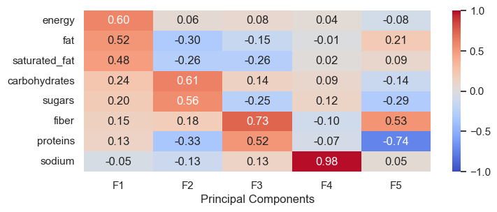

```python
heatmap_PCA(OFF_data_scaled[columns_pca],pca_n_components)
```

Some observation from the heatmap:

```
- F4 doesn't hold much information other than high weight on sodium. F4 is purely the sodium column.
- Since Sodium is mostly 1 on F4 axis and not contributing much to the other components, we can consider Sodium as not much correlated to the other columns. We are doing dimension reduction, therefore Sodium can be dropped from the PCA along with its dimension.
```

From the observation extracted from the heatmap, first we will drop the sodium form the PCA, and reducing the number of pca components to 4 since we removed the sodium which should remove F4.

```python
columns_pca = ['energy', 'fat', 'saturated_fat', 'carbohydrates', 'sugars', 'fiber', 'proteins']
pca_n_components = 4
pca = PCA(pca_n_components)
pca.fit(OFF_data_scaled[columns_pca])
OFF_data_scaled_pca = pca.transform(OFF_data_scaled[columns_pca])
```

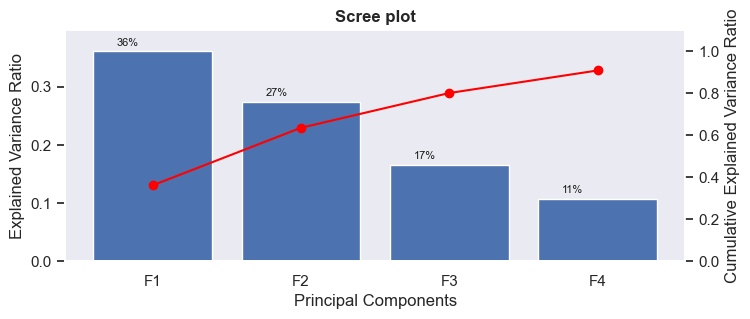

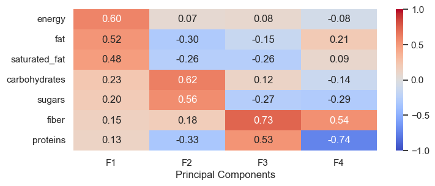

```python
scree_plot_explained_variance_ratio(pca_n_components)
heatmap_PCA(OFF_data_scaled[columns_pca], pca_n_components)
```

Removing Sodium didn't change much to the 4 components values as expected. Now the focus should be on analysing these 4 components. To that end, I'm going to plot the correlation graph between F1 and F2, then F3 and F4.

```python
# Function copied from openclassrooms https://colab.research.google.com/drive/1TKe1_1ECzOlP4Aj1P3vzbn47U9YrqVFQ#scrollTo=HLYtZl7z_kk5
def correlation_graph(pca, x_y, features) :
    """Affiche le graphe des correlations

    Positional arguments :
    -----------------------------------
    pca : sklearn.decomposition.PCA : notre objet PCA qui a été fit
    x_y : list ou tuple : le couple x,y des plans à afficher, exemple [0,1] pour F1, F2
    features : list ou tuple : la liste des features (ie des dimensions) à représenter
    """

    # Extrait x et y
    x,y = x_y

    # Taille de l'image (en inches)
    fig, ax = plt.subplots(figsize=(6, 6))

    # Pour chaque composante :
    for i in range(0, pca.components_.shape[1]):

        # Les flèches
        ax.arrow(0, 0,
                 pca.components_[x, i],
                 pca.components_[y, i],
                 head_width=0.07,
                 head_length=0.07,
                 width=0.02)

        # Les labels
        plt.text(pca.components_[x, i] + 0.05,
                 pca.components_[y, i] + 0.05,
                 features[i])

    # Affichage des lignes horizontales et verticales
    plt.plot([-1, 1], [0, 0], color='grey', ls='--')
    plt.plot([0, 0], [-1, 1], color='grey', ls='--')

    # Nom des axes, avec le pourcentage d'inertie expliqué
    plt.xlabel('F{} ({}%)'.format(x+1, round(100*pca.explained_variance_ratio_[x],1)))
    plt.ylabel('F{} ({}%)'.format(y+1, round(100*pca.explained_variance_ratio_[y],1)))
    plt.title("Cercle des corrélations (F{} et F{})".format(x+1, y+1))

    # Le cercle
    an = np.linspace(0, 2*np.pi, 100)
    plt.plot(np.cos(an), np.sin(an))  # Add a unit circle for scale

    # Axes et display
    plt.axis('equal')
    plt.show(block=False)
```

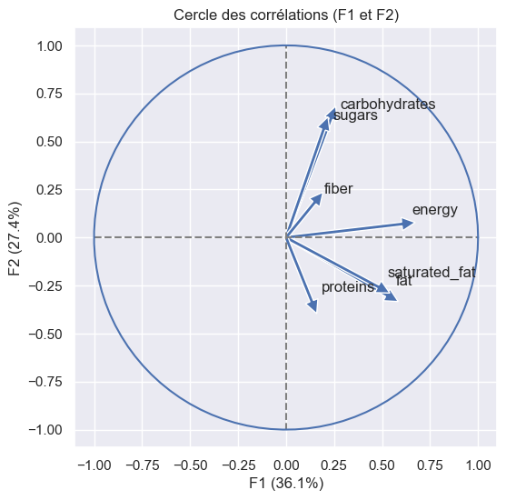

```python
correlation_graph(pca, (0, 1), OFF_data_scaled[columns_pca].columns)
```

Observation from the correlation circle between F1 and F2 components:

```
- Projection into F1 axis, we can see that the fat and sat_fat contribute the most to the value of energy, and the protein, sugars, carbohydrates, and fiber contribute the lesser level to the energy. To summarize, F1 component can be refered to as the energy axis.
- Projection into F2 axis, we can see that fat and sat_fat belong to the same group, and that sugar and carbohydrate belong to the same group as well.
```

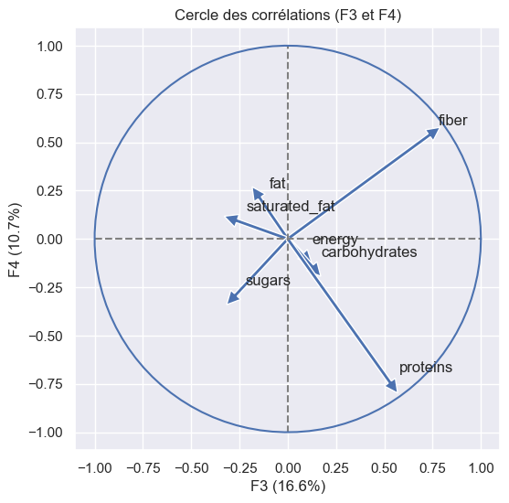

```python
correlation_graph(pca, (2, 3), OFF_data_scaled[columns_pca].columns)
```

```
- The plan created by F3 and F4 can be considered as the protein and fiber plan since they are close to the circle edge.
- Projecting into F3 axis, fiber, protein, and to a lesser degree carbohydrate are on the positive side and sugars, saturated_fat, and fat are on the negative side. We can say that this axis might be related to the good (+) versus bad (-) nutrients.
- Projecting into F4 component, we can see that protein is at the opposite side of fiber. That might be due to most protein foods are low on fibers. F4 axis can be refered to the axis of protein and fiber contents in food.
```

Now we can focus on projecting the products on (F1,F2) and (F3,F4) plans according to their nutri-score, or to their pnns_groups_1.

```python
# Plotting a sample of values projected on first factorial planes
index_df_sample = pd.Series(OFF_data_scaled.index).sample(500)
X_sample = OFF_data_scaled.loc[index_df_sample, OFF_data_scaled.columns].values
X_sc_samp = StandardScaler().fit_transform(X_sample)
```

```python
# Function copied from openclassrooms https://colab.research.google.com/drive/1TKe1_1ECzOlP4Aj1P3vzbn47U9YrqVFQ#scrollTo=HLYtZl7z_kk5
def display_factorial_planes(X_projected,
                             x_y,
                             pca=None,
                             labels=None,
                             clusters=None,
                             alpha=1,
                             figsize=[10, 8],
                             marker='.'):
    """
    Affiche la projection des individus

    Positional arguments :
    -------------------------------------
    X_projected : np.array, pd.DataFrame, list of list : la matrice des points projetés
    x_y : list ou tuple : le couple x,y des plans à afficher, exemple [0,1] pour F1, F2

    Optional arguments :
    -------------------------------------
    pca : sklearn.decomposition.PCA : un objet PCA qui a été fit, cela nous permettra d'afficher la variance de chaque composante, default = None
    labels : list ou tuple : les labels des individus à projeter, default = None
    clusters : list ou tuple : la liste des clusters auquel appartient chaque individu, default = None
    alpha : float in [0,1] : paramètre de transparence, 0=100% transparent, 1=0% transparent, default = 1
    figsize : list ou tuple : couple width, height qui définit la taille de la figure en inches, default = [10,8]
    marker : str : le type de marker utilisé pour représenter les individus, points croix etc etc, default = "."
    """

    # Transforme X_projected en np.array
    X_ = np.array(X_projected)

    # On définit la forme de la figure si elle n'a pas été donnée
    if not figsize:
        figsize = (7, 6)

    # On gère les labels
    if  labels is None :
        labels = []
    try :
        len(labels)
    except Exception as e :
        raise e

    # On vérifie la variable axis
    if not len(x_y) == 2 :
        raise AttributeError('2 axes sont demandées')
    if max(x_y ) >= X_.shape[1] :
        raise AttributeError('la variable axis n'est pas bonne')

    # on définit x et y
    x, y = x_y

    # Initialisation de la figure
    fig, ax = plt.subplots(1, 1, figsize=figsize)

    # On vérifie s'il y a des clusters ou non
    c = None if clusters is None else clusters

    # Les points
    # plt.scatter(X_[:, x], X_[:, y], alpha=alpha,
    #             c=c, cmap="Set1", marker=marker)
    sns.scatterplot(data=None, x=X_[:, x], y=X_[:, y], hue=c,
                    hue_order=clusters.sort_values().unique())

    # Si la variable pca a été fournie, on peut calculer le % de variance de chaque axe
    if pca :
        v1 = str(round(100*pca.explained_variance_ratio_[x]))  + " %"
        v2 = str(round(100*pca.explained_variance_ratio_[y]))  + " %"
    else :
        v1 = v2 = ''

    # Nom des axes, avec le pourcentage d'inertie expliqué
    ax.set_xlabel(f'F{x+1} {v1}')
    ax.set_ylabel(f'F{y+1} {v2}')

    # Valeur x max et y max
    x_max = np.abs(X_[:, x]).max()*1.1
    y_max = np.abs(X_[:, y]).max()*1.1

    # On borne x et y
    ax.set_xlim(left=-x_max, right=x_max)
    ax.set_ylim(bottom= -y_max, top=y_max)

    # Affichage des lignes horizontales et verticales
    plt.plot([-x_max, x_max], [0, 0], color='grey', alpha=0.8)
    plt.plot([0, 0], [-y_max, y_max], color='grey', alpha=0.8)

    # Affichage des labels des points
    if len(labels) :
        for i, (_x, _y) in enumerate(X_[:, [x, y]]):
            plt.text(_x, _y+0.05, labels[i], fontsize='14',
                     ha='center', va='center')

    # Titre et display
    plt.title(f"Projection des individus (sur F{x+1} et F{y+1})")
    plt.show()
```

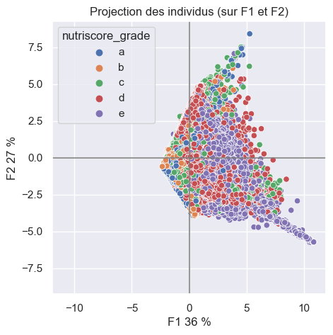

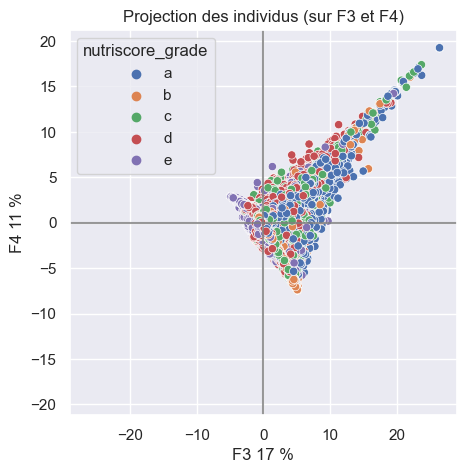

```python
display_factorial_planes(OFF_data_scaled_pca, [0, 1], pca,
                         clusters=OFF_data['nutriscore_grade'], figsize=[5, 5])
display_factorial_planes(OFF_data_scaled_pca, [2, 3], pca,
                         clusters=OFF_data['nutriscore_grade'], figsize=[5, 5])
```

- Projecting into F1, we can see that the higher the energy (higher positive value on F1), the more d and e nutri_grade become dominant. This seems logic since there is positive correlation between products high on energy and the low nutritional value of the product.
- We cannot say much projecting on F2. This means that there is no much correlation between the macronutrients (fat, carbs, and protein) and the nutriscore.
- Projecting into F3, we can see that the higher the nutri-grade (d and e grades), the lower (also negative) the F3 component become. This seems logic since fat, saturated_fat, and sugar are located in the negative part of F3 component which correspond to low nutritional value of the product. Protein, fiber, and to a lesser degree carbohydrate are located in the positive side of F3 component which correspond to better nutri-grade (a and b grades, i.e. high nutritional value of the product).
- Projecting into F4, we can't say much.

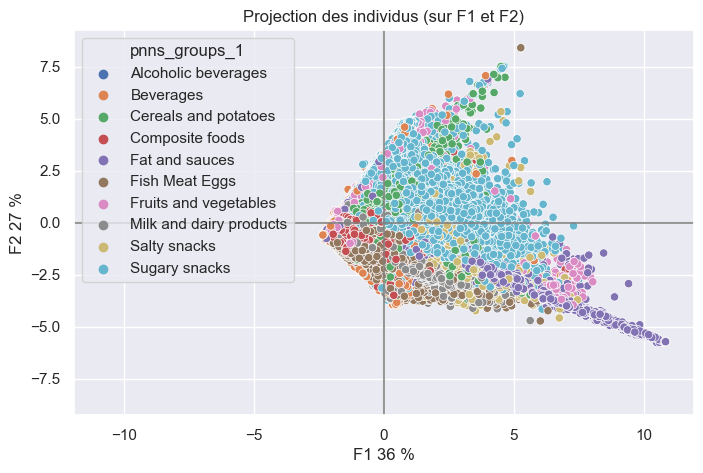

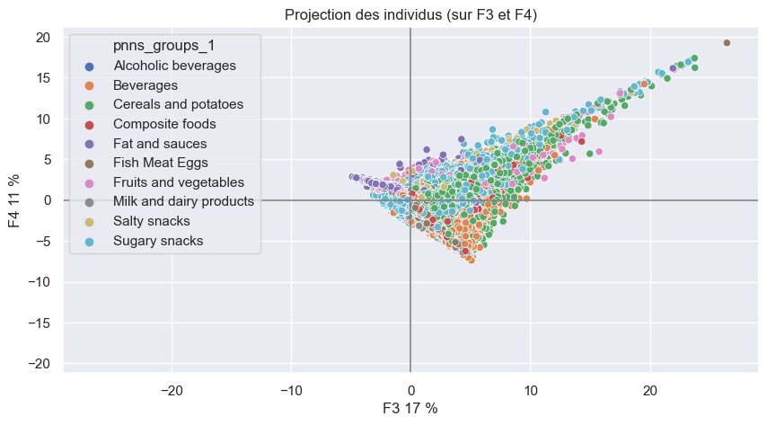

```python
display_factorial_planes(OFF_data_scaled_pca, [0, 1], pca,
                         clusters=OFF_data['pnns_groups_1'], figsize=[8, 5])
display_factorial_planes(OFF_data_scaled_pca, [2, 3], pca,
                         clusters=OFF_data['pnns_groups_1'], figsize=[10, 5])
```

## 3. Extracting the data

```python
# Extracting data without the dimension reduction via PCA
OFF_data = OFF_data.reset_index(drop=True)
OFF_data.to_csv('openfoodfacts_products_data_final.csv', sep='\t', index=False)
```

```python
# Extracting data with the dimension reduction via PCA
OFF_data_scaled_pca = pd.DataFrame(OFF_data_scaled_pca)
column=['PCA_F1', 'PCA_F2', 'PCA_F3', 'PCA_F4']
OFF_data[column] = OFF_data_scaled_pca
```

```python
colomn = ['code', 'product_name', 'brands', 'pnns_groups_1', 'pnns_groups_2',
          'nutriscore_grade', 'nutriscore_score',
          'PCA_F1', 'PCA_F2', 'PCA_F3', 'PCA_F4', 'sodium']
OFF_data[column].to_csv('openfoodfacts_products_data_pca_reduced_final.csv', sep='\t', index=False)
```

## 4. Application

The idea is based on product recommendation based on nutris-core and nutri-grade.

- **I- User input**: the user will input the product name or scan the barcode of the product.
- **II- Application search of the product**: the application will search the product in the database and the nutritional information related to the product.
  - If the product is not in the database, the application will output to the user that the product in not found in the database.
  - If the product is in the database, the application will proceed to the next step.
    - **III- Application check of the product**:
      - If the nutri-grade of the product is a, the application will not recommand another product for the user, the application will just display the nutri-grade of the product to the user.
      - If the nutri-grade of the product is not a, the application will search for similar products in the database based on pnns_group_2. The application will proceed to the next step.
        - **IV- Application selection of better nutri-grade products:** From that pool of similar products, the application will select only those with better nutri-grade.
          - **V- Application selection of the best nutri-score product:** From those products with better nutri-grade, the application will display to the user the product with the best nutri-score.

## 5. Conclusion and Future improvement

Conclusion:

- From all the column in the initial database, we select only the most important columns. There is other columns that are needed for future improvement of the application and for better selection/recommendation of the products to the user but they are less important at this stage of the application.
- The analysis helped to drop Nova_group and fruit-vegetable-nuts column from our databse sinc ethey don't make sense. Using ACP, we can reduce dimentionally our 7 nutrional contents variables into 4 dimensions. The pnns_group_1 can also be dropped since pnns_group_2 is provided in the database. This reduce the dimension of our databse to 11 variables.

For future improvement:

- If the input product is not in the database, the application can ask the user to input the nutritional informations or take an photo of the product as well aa a photo of the product nutritional informations. This information can then be used to input that product to the database and perform the cleaning procedure in the cleaning_notebook.
- The application can use the IP address of the user to recommend a product sold in that country. For that, the column countries have to be included in the cleaning notebook.
- Following that, the application can also use the ecoscore_grade to recommend a product with better ecoscore. For that, the column ecoscore have to be included in the cleaning notebook.